# Exploratory Analysis

## Project title

Technology Company Layoffs Research and Analysis

### Authors

Andy Li

Dustin Duc Duy Nguyen

Edward Newell

Guillermo Andres Melendez-Carlson

### Date

February 20th, Winter 2023

### Abstract

Our main question is how did the layoff numbers varies from different companies and how would it impact the associate companies? This question is important because with the current economic situation, the layoff numbers could cause indiviudals to lose their only source of income. To address this concern, we plan to analyze a large data set that contains the amount of layoffs from different companies.

### Keywords

Tech Layoffs, Technology Comapanies, COVID-19 Pandemic

### Introduction

In this assignment, our goal was to investigate the recent rise of layoffs in the tech industry. This is relevant to many in this class, as most want a job in this sector. Looking into this will help us prepare a significant risk in our future. Our three associated questions are:

1. What kind of companies have been laying off the most?
2. What is the total number of layoffs over the past year?
3. How have layoffs increased in the past year?

By asking what companies are most impacted, we can get a good picture of where in the tech industry is most unstable. Figuring out the total number of layoffs will give us a sense of skill to identify the scale of this issue. Lastly, by analyzing changes in throughout the year, we can hopefully discover growth trends and make predictions about the future.

### Related Work

The COVID-19 pandemic has dramatically impacted the economy of the United States. For many industries, this meant major job losses, as companies couldn’t sustain employing their typical amount of workers when the world crawled to a halt. Some industries, however, faced a “hiring boom” as demand increased for their services. This included necessities such as retail and medicine workers, as well as jobs in tech. After an initial spike of layoffs in 2020, many tech companies such as Netflix and Amazon found a major increase of consumers relying on their products to get through the quarantine, resulting in an industry-wide rush to hire for the increased demand. Yet, it seems most of these companies overestimated their demand for labor, and are now facing massive layoffs to stay afloat. A CNBC article titled [“Tech jobs were hit the hardest by layoffs last year”](https://www.cnbc.com/2023/01/05/tech-jobs-hit-the-hardest-by-layoffs-last-year-report.html) provides examples of these instances, and notes how 2022 had nearly a 649% increase in layoffs compared to the year before. They found “cost cutting” to be the most common given reason for these layoffs, with “market or economic conditions” following closely. A Bloomberg article titled [“What 2022 tech layoffs say about Silicon Valley, the economy”](https://www.bloomberg.com/news/articles/2023-01-18/what-2022-tech-layoffs-say-about-silicon-valley-the-economy) provides an in-depth exploration of these layoffs, seeking to explain their most likely causes and the aftermath of these decisions. Taking data from the site [Layoffs.fyi](https://layoffs.fyi/), the article charts out the largest companies impacted, and notes how this is the biggest series of layoffs in the tech industry since the infamous 2001 dot-com bubble market crash. Looking at public statements from major CEOs, the researchers found that the most likely given reason for this crash was overconfident optimism on the companies’ future trajectories “based on assumptions of ever-increasing growth,” worsened only by the outlier demand for their services during COVID lockdown. The article also described the various ways companies are responding to this issue, ranging from covering up the irregular behavior, to getting bought, to offering ex-employees generous severance packages to keep good press. An article from the New York Times titled [“For tech companies, years of easy money yield to Hard Times”](https://www.nytimes.com/2023/01/23/technology/tech-interest-rates-layoffs.html) offers a different explanation for these companies’ struggles, using the startup Carvana as reference. Their takeaway from these major tech companies facing economic hardship is that it’s due to interest rates rising during the pandemic. For a long time, tech companies were acquiring funding from investors at very low interest rates. This allowed these companies to operate fairly cheaply, and support growth even while the company isn’t profitable. With the pandemic - interest rates had to rise - and many tech companies are now facing a rude awakening that they may no longer operate off what the article calls “cheap money,” and that they can’t afford to keep expanding at the rate they were before this shift.

References

Feiner, L. (2023, January 5). Tech jobs were hit the hardest by layoffs last year. CNBC. Retrieved February 2, 2023, from https://www.cnbc.com/2023/01/05/tech-jobs-hit-the-hardest-by-layoffs-last-year-report.html

Carr, A., & McBride, S. (2023, January 18). What 2022 tech layoffs say about Silicon Valley, the economy. Bloomberg.com. Retrieved February 2, 2023, from https://www.bloomberg.com/news/articles/2023-01-18/what-2022-tech-layoffs-say-about-silicon-valley-the-economy

Streitfeld, D. (2023, January 23). For tech companies, years of easy money yield to Hard Times. The New York Times. Retrieved February 2, 2023, from https://www.nytimes.com/2023/01/23/technology/tech-interest-rates-layoffs.html

### The Dataset

The data we are using is “Technology Company Layoffs”. We found the data from the website Kaggle. The collaborator for this project is Widya Salim. This data was collected from various news sources and direct company websites, including but not limited to TechCrunch, GeekWire, CNBC, World Street Journal, Linkedin, Bloomberg and Business Insider. The reason for its creation includes gaining insights on technology industry trends and making informed decisions for an individual’s own career or business. There are 477 rows representing the different tech companies, with 9 columns each representing company, total lay_offs, impacted_workforce_percentage, Industry, headquarter_location, sources, reported date, status, and additional notes. One problem that came across is that since the data was released through direct company websites, there is the possibility that companies might increase or decrease the actual percentages of laid_off employees to hold their market status. For example they could decrease the recorded amount of laid-off employees to show their power in holding the current market value of the company. With a decreased amount of recorded laid-off workers, it would prove that the company is still strong enough for any investments compared to other similar companies within the same field. In addition, sources recorded from news sources also have some hidden risks. News companies make profit through the influenece and amount of viewers of the news, so they could adjust the numbers large enough to attract more viewers, which might not be an accurate representation of the data,

https://www.kaggle.com/datasets/salimwid/technology-company-layoffs-20222023-data

### Implications

Our project aims to better understand the context of tech company layoffs. Depending on how our research questions are answered, technologists and designers may be facing an even more competitive job market which means that they would need to demonstrate their value and skills in a tighter labor market. They may also need to consider other career paths such as freelancing or starting their own business to maintain their income and job security.

For policymakers, an increase in layoffs may heighten the need for support programs and policies to help those who have been impacted by the job loss, as well as an incentive to boost the economy and create new job opportunities. Additionally, this may also raise questions about the role of technology in the economy. It’s worth noting that the COVID-19 pandemic has had a significant impact on the global economy, and many companies across different industries have had to make difficult decisions pertaining to layoffs in order to stay afloat.

### Limitations & Challenges

One limitation we may face is that our dataset will not contain information on all layoffs that have occurred and will occur in the future. This means that we may be missing data on smaller or less well-publicized layoffs. The missing data might also be related to data confidentiality, where companies may be reluctant to publicy disclose information on layoffs. This could limit the amount of data available in the set and make it difficult to draw conclusions about the scale and nature of layoffs.

As our project is researching an occurring event, this means that certain data in our set is subject to change. This makes the reliability of our data a potential limitation, especially since our data is collected from various sources, meaning a higher risk of inaccuracy. It’s possible that our data may need to be supplemented with additional information from other sources to gain a more complete understanding of the issue.

### Table

Top five companies impacted by the layoffs

| company | num_layoffs | industry |
| --- | --- | --- |
| Amazon | 18000 | E-commerce, SaaS |
| Alphabet | 12000 | Big tech, internet services |
| Meta | 11000 | Social media |
| Microsoft | 10000 | Enterprise Software |
| Salesforce | 9090 | enterprise tech, analytics |

This table shows the number of layoffs from companies ranked in order. We noticed that Amazon has the highest number of layoffs with 18000. This table is important because it helps us to visualize the amount of layoffs from companies, and also seeing the pattern that larger tech companies such as Amazon and Microsoft has the highest number of people laid off.

### Chart 1: Sources

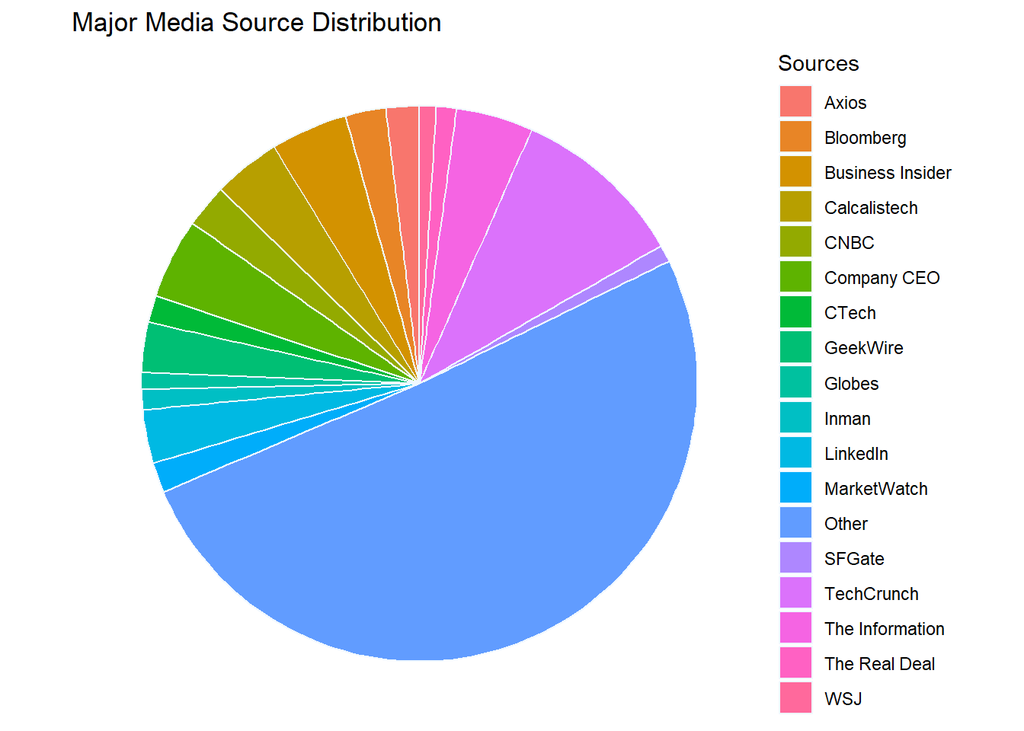

This pie chart displays the journalist sources that the dataset attributes to announcing Tech Company Layoffs. Each “slice” of the pie is attributed to a major media source. For the sake of simplicity and clarity, every instance in which a company’s CEO announced the layoffs publicly was merged into one “Company CEO” category, and every media source that reported the layoffs of fewer than 5 companies was merged into the “other” category.

I chose a pie chart to represent this data, because I wanted to examine which media companies have done the most reporting on the layoffs. Pie charts display proportions well, showing the percentage each variable takes up from the total.

This chart is important because it shows which media companies are the most proactive at reporting important tech news. This can influence where consumers go for information about the subject.

[figure not shown]

I chose a bar graph because I was comparing the proportions of each category, but independent from one another instead of their percentage of one whole. Initially I chose to compare the number of layoffs in each industry, but those results were fairly predictable being tied to the biggest industries worker-wise. So instead, I chose to compare the average percent of each industry that has been laid off, hoping to find results that are more descriptive of how each industry has actually been affected.

### Chart 3: Impacted Workforce Percentage by Reported Date

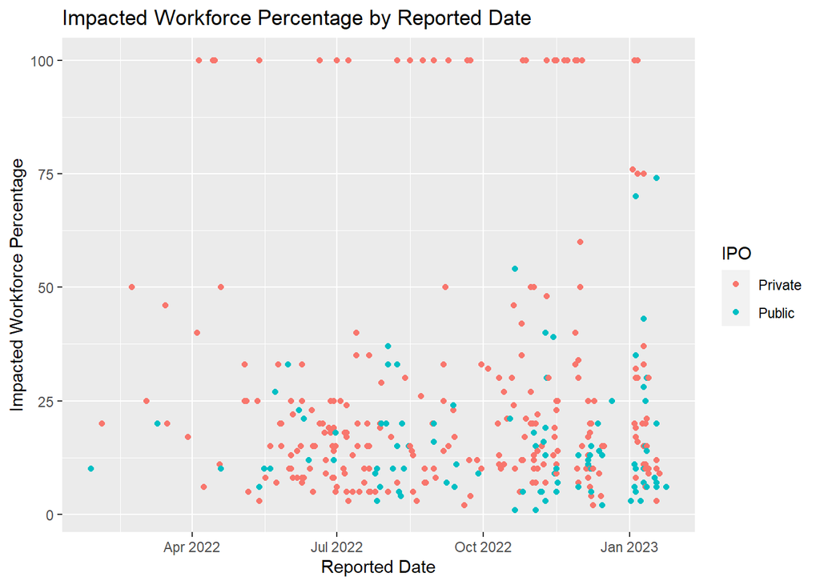

This scatterplot plots all companies recorded impacted workforce percentage by the reported date. The color of each dot is determined by whether they are a public or private company.

This graph is important because it shows that the tech industry is still currently going through layoffs with no signs of slowing down. This could continue until at least the end of the year. For people looking for jobs in the tech industry, this means that they should be prepared for open position to be more competitive and will have to work to stand out from other applicants. Additionally, it is more riskier applying to private companies for the time being as layoffs tend to have more impact there.